# Predicting Tumor Malignancy: A Comparative Study of Supervised Learning Models with Ensemble Techniques

Boning Liu

11-14-2024

# 1 Introduction

In this project, I will be exploring and applying supervised learning techniques to predict the classification of breast cancer tumors as either malignant or benign. The objective is to develop a predictive model using a dataset containing various tumor attributes, derived from medical imaging. By implementing and comparing different machine learning models, such as logistic regression and a single-layer neural network, I aim to identify which model provides the highest predictive accuracy.

Key Questions We Are Trying to Solve:

- Can we accurately classify tumors as malignant or benign based on their physical characteristics?
- Which machine learning model offers the best performance for this classification task?
- What are the sensitivity and specificity of each model, and how well do they perform in terms of overall accuracy?
- How does the performance of simpler models (e.g., logistic regression) compare to more complex models (e.g., neural networks and decision trees)?

To assess the performance of these models, I will use metrics such as accuracy, sensitivity, specificity, and the area under the Receiver Operating Characteristic (ROC) curve. Additionally, I will evaluate each model’s effectiveness in distinguishing between malignant and benign tumors to determine the best-performing model. This analysis not only demonstrates practical applications of machine learning in the healthcare domain but also highlights the strengths and weaknesses of various predictive algorithms.

## 1.1 Data Set

For this analysis, I am using the Breast Cancer Wisconsin (Diagnostic) Dataset. This dataset is publicly available on Kaggle and originates from the UCI Machine Learning Repository. It includes 569 observations with 30 attributes that describe characteristics of cell nuclei present in digital images of breast masses. These characteristics are used to predict the binary outcome: Malignant (coded as 1) or Benign (coded as 0).

Key Variables in the Dataset:

- **diagnosis**: Diagnosis of tumor (Malignant/Benign) - **Categorical** (**Binary**)
- **radius_mean**: Mean of distances from center to points on the perimeter - **Numerical**
- **texture_mean**: Standard deviation of gray-scale values - **Numerical**
- **perimeter_mean**: Mean size of the tumor perimeter - **Numerical**
- **area_mean**: Mean area of the tumor - **Numerical**
- **smoothness_mean**: Mean of local variation in radius lengths - **Numerical**
- **compactness_mean**: Mean of the perimeter squared divided by the area - **Numerical**
- **concavity_mean**: Mean severity of concave portions of the contour - **Numerical**
- **concave points_mean**: Mean number of concave portions of the contour - **Numerical**
- **symmetry_mean**: Mean symmetry of the tumor - **Numerical**
- **fractal_dimension_mean**: Mean “coastline approximation” of the tumor - **Numerical**

Additional features include “standard error” (SE) values and “worst” (largest) values for each of these characteristics, allowing for more detailed descriptions of each tumor’s features.

This dataset provides a robust set of predictors, enabling the development of a highly accurate classification model to predict whether a tumor is malignant or benign.

```r
# Load necessary libraries
library(caret)
library(pROC)

# Set your working directory to where the file is stored
setwd("C:/Users/brian/OneDrive/Desktop/WCU GRAD SCHOOL/Fall 2024/STA 551/STA 551")

# Read the dataset
breast_cancer_data <- read_csv("breastcancer.csv")

# Remove the unnecessary column if it contains only NA values
breast_cancer_data <- breast_cancer_data %>%
  select(-`...33`)

# Convert diagnosis to binary (1 for Malignant, 0 for Benign)
breast_cancer_data <- breast_cancer_data %>%
  mutate(diagnosis = ifelse(diagnosis == "M", 1, 0))
```

# 2 EDA

## 2.1 Summary Statistics

```r
# Summary of the dataset
summary(breast_cancer_data)
```

```
       id              diagnosis       radius_mean      texture_mean
 Min.   :     8670   Min.   :0.0000   Min.   : 6.981   Min.   : 9.71
 1st Qu.:   869222   1st Qu.:0.0000   1st Qu.:11.707   1st Qu.:16.17
 Median :   906157   Median :0.0000   Median :13.375   Median :18.84
 Mean   : 30425140   Mean   :0.3732   Mean   :14.139   Mean   :19.28
 3rd Qu.:  8825022   3rd Qu.:1.0000   3rd Qu.:15.797   3rd Qu.:21.79
 Max.   :911320502   Max.   :1.0000   Max.   :28.110   Max.   :39.28
 perimeter_mean     area_mean      smoothness_mean   compactness_mean
 Min.   : 43.79   Min.   : 143.5   Min.   :0.06251   Min.   :0.01938
 1st Qu.: 75.20   1st Qu.: 420.3   1st Qu.:0.08640   1st Qu.:0.06517
 Median : 86.29   Median : 551.4   Median :0.09589   Median :0.09312
 Mean   : 92.05   Mean   : 655.7   Mean   :0.09644   Mean   :0.10445
 3rd Qu.:104.15   3rd Qu.: 784.1   3rd Qu.:0.10533   3rd Qu.:0.13043
 Max.   :188.50   Max.   :2501.0   Max.   :0.16340   Max.   :0.34540
 concavity_mean    concave points_mean symmetry_mean    fractal_dimension_mean
 Min.   :0.00000   Min.   :0.00000     Min.   :0.1060   Min.   :0.04996
 1st Qu.:0.02958   1st Qu.:0.02035     1st Qu.:0.1620   1st Qu.:0.05770
 Median :0.06155   Median :0.03360     Median :0.1792   Median :0.06155
 Mean   :0.08896   Mean   :0.04901     Mean   :0.1812   Mean   :0.06280
 3rd Qu.:0.13100   3rd Qu.:0.07401     3rd Qu.:0.1957   3rd Qu.:0.06613
 Max.   :0.42680   Max.   :0.20120     Max.   :0.3040   Max.   :0.09744
   radius_se        texture_se      perimeter_se       area_se
 Min.   :0.1115   Min.   :0.3602   Min.   : 0.757   Min.   :  6.802
 1st Qu.:0.2324   1st Qu.:0.8331   1st Qu.: 1.605   1st Qu.: 17.850
 Median :0.3240   Median :1.1080   Median : 2.285   Median : 24.565
 Mean   :0.4052   Mean   :1.2165   Mean   : 2.867   Mean   : 40.374
 3rd Qu.:0.4798   3rd Qu.:1.4743   3rd Qu.: 3.360   3rd Qu.: 45.237
 Max.   :2.8730   Max.   :4.8850   Max.   :21.980   Max.   :542.200
 smoothness_se      compactness_se      concavity_se     concave points_se
 Min.   :0.001713   Min.   :0.002252   Min.   :0.00000   Min.   :0.000000
 1st Qu.:0.005166   1st Qu.:0.013133   1st Qu.:0.01510   1st Qu.:0.007663
 Median :0.006374   Median :0.020460   Median :0.02592   Median :0.010950
 Mean   :0.007041   Mean   :0.025515   Mean   :0.03195   Mean   :0.011817
 3rd Qu.:0.008151   3rd Qu.:0.032455   3rd Qu.:0.04212   3rd Qu.:0.014730
 Max.   :0.031130   Max.   :0.135400   Max.   :0.39600   Max.   :0.052790
  symmetry_se       fractal_dimension_se  radius_worst   texture_worst
 Min.   :0.007882   Min.   :0.0008948    Min.   : 7.93   Min.   :12.02
 1st Qu.:0.015128   1st Qu.:0.0022445    1st Qu.:13.03   1st Qu.:21.07
 Median :0.018725   Median :0.0031955    Median :14.97   Median :25.41
 Mean   :0.020531   Mean   :0.0037967    Mean   :16.28   Mean   :25.67
 3rd Qu.:0.023398   3rd Qu.:0.0045585    3rd Qu.:18.80   3rd Qu.:29.68
 Max.   :0.078950   Max.   :0.0298400    Max.   :36.04   Max.   :49.54
 perimeter_worst    area_worst     smoothness_worst  compactness_worst
 Min.   : 50.41   Min.   : 185.2   Min.   :0.07117   Min.   :0.02729
 1st Qu.: 84.15   1st Qu.: 515.7   1st Qu.:0.11660   1st Qu.:0.14758
 Median : 97.67   Median : 686.5   Median :0.13135   Median :0.21300
 Mean   :107.35   Mean   : 881.7   Mean   :0.13244   Mean   :0.25460
 3rd Qu.:125.53   3rd Qu.:1085.0   3rd Qu.:0.14602   3rd Qu.:0.33930
 Max.   :251.20   Max.   :4254.0   Max.   :0.22260   Max.   :1.05800
 concavity_worst  concave points_worst symmetry_worst   fractal_dimension_worst
 Min.   :0.0000   Min.   :0.00000      Min.   :0.1565   Min.   :0.05504
 1st Qu.:0.1159   1st Qu.:0.06497      1st Qu.:0.2504   1st Qu.:0.07147
 Median :0.2275   Median :0.10002      Median :0.2821   Median :0.08005
 Mean   :0.2727   Mean   :0.11481      Mean   :0.2901   Mean   :0.08397
 3rd Qu.:0.3835   3rd Qu.:0.16168      3rd Qu.:0.3180   3rd Qu.:0.09208
 Max.   :1.2520   Max.   :0.29100      Max.   :0.6638   Max.   :0.20750
```

**Diagnosis Variable**:

The diagnosis variable has values of 0 and 1, corresponding to Benign (0) and Malignant (1), respectively. The data appears to be imbalanced, with more benign cases than malignant ones (based on the summary statistics showing a higher mean for 0).

**Numerical Variables**:

radius_mean, texture_mean, perimeter_mean, area_mean, etc.: These are the key numerical features derived from the breast mass images. The summary shows the range of values for these variables, which indicates the spread and variation across the dataset. For example, radius_mean has a range from 6.98 to 28.11, indicating variation in the tumor sizes.

The large differences between the mean and median for some variables, such as radius_worst (mean = 16.28, median = 14.97), suggest potential skewness in their distributions. This would be an important consideration for modeling, as skewed data can impact model performance, especially for linear models like logistic regression.

Variables like concavity_worst, compactness_worst, and fractal_dimension_worst show some higher values in the max category, indicating potential outliers or extreme values.

## 2.2 Analysis of Target Variable Distribution

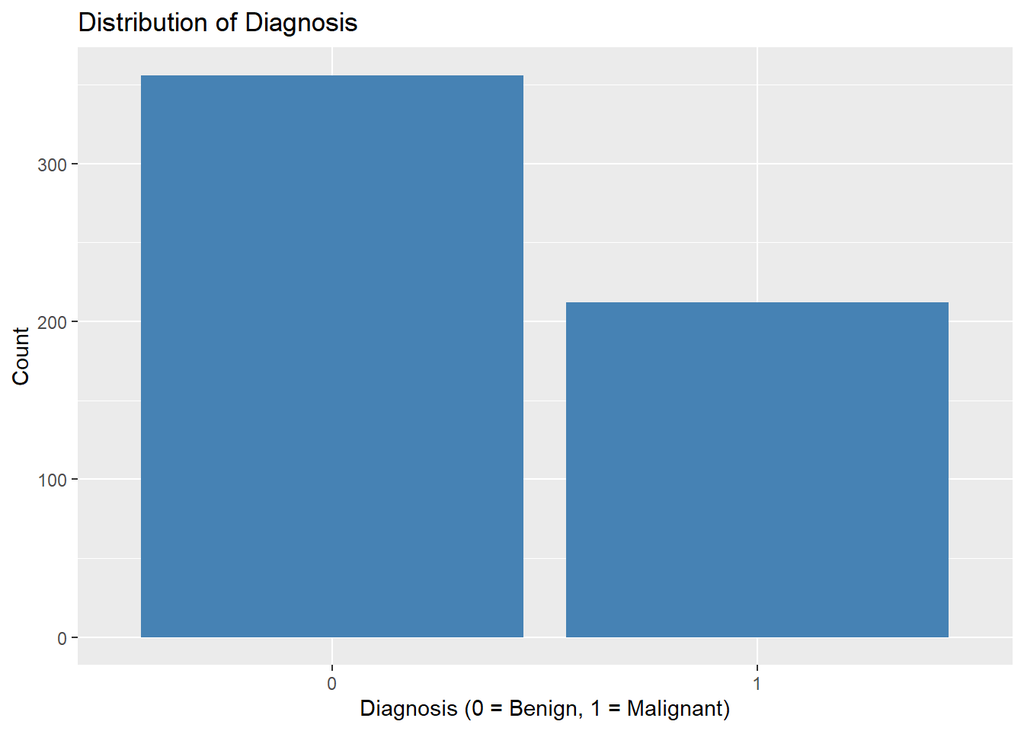

```r
library(ggplot2)

# Bar plot for target variable 'diagnosis'
ggplot(breast_cancer_data, aes(x = factor(diagnosis))) +
  geom_bar(fill = "steelblue") +
  labs(title = "Distribution of Diagnosis", x = "Diagnosis (0 = Benign, 1 = Malignant)", y = "Count")
```

The bar plot above shows the distribution of the target variable, diagnosis, which indicates whether a breast tumor is benign (0) or malignant (1). From the plot, it is evident that:

- There are more benign cases than malignant cases in this dataset.
- The count of benign tumors (coded as 0) is significantly higher than the count of malignant tumors (coded as 1). Specifically, we observe that approximately two-thirds of the cases are benign, while one-third are malignant.

This imbalance in the target variable is important to consider, as it may affect model performance. Models trained on imbalanced data may be biased toward the majority class (benign in this case), leading to higher accuracy for benign predictions but potentially lower accuracy for malignant predictions. To address this, we may need to explore methods such as adjusting class weights or using techniques like resampling or synthetic data generation in future modeling steps.

## 2.3 Distribution of Key Predictors

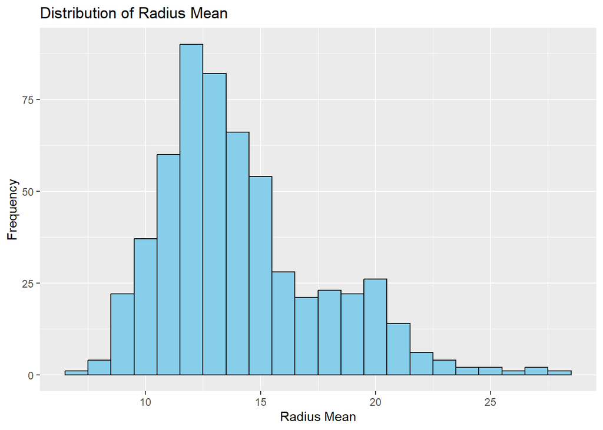

```r
# Histograms for key numerical variables
ggplot(breast_cancer_data, aes(x = radius_mean)) +
  geom_histogram(binwidth = 1, fill = "skyblue", color = "black") +
  labs(title = "Distribution of Radius Mean", x = "Radius Mean", y = "Frequency")
```

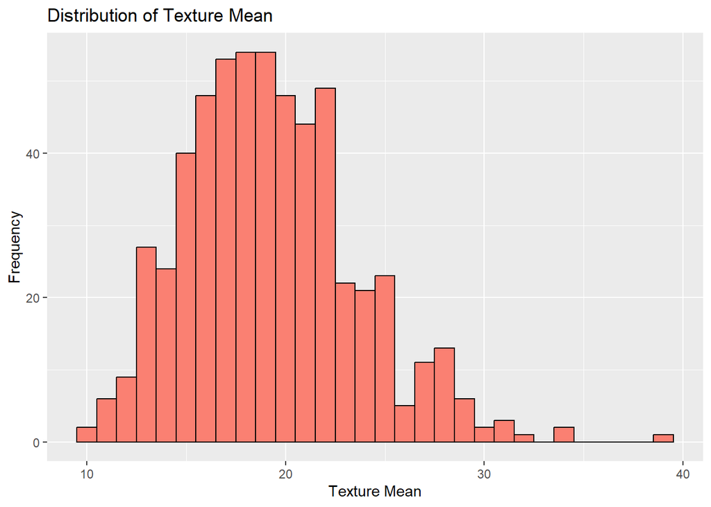

```r
ggplot(breast_cancer_data, aes(x = texture_mean)) +
  geom_histogram(binwidth = 1, fill = "salmon", color = "black") +
  labs(title = "Distribution of Texture Mean", x = "Texture Mean", y = "Frequency")
```

The histograms above illustrate the distributions of two important predictor variables, Radius Mean and Texture Mean, in the dataset.

1. **Radius Mean**:
- The **radius_mean** variable, which represents the average distance from the center of the tumor to points on its perimeter, shows a right-skewed distribution. The majority of values are concentrated between 10 and 15, with a few cases extending up to around 25.
- This skewness suggests that a larger number of tumors have smaller radius values, with fewer cases having large radii. The presence of some high values might indicate potential outliers or tumors with significantly larger radii.
2. **Texture Mean**:
- The **texture_mean** variable, representing the standard deviation of gray-scale values in the tumor images, has a distribution closer to normal, though it is slightly right-skewed. Most values fall between 15 and 25, with a peak around 20.
- This relatively normal distribution suggests a more balanced spread of texture values across the dataset. The range, however, still extends from below 10 to nearly 40, indicating a moderate level of variability.

These distributions are important to consider for modeling, as skewed variables may affect model assumptions and performance, particularly in linear models. Transformations, such as logarithmic or square root transformations, might be considered to normalize these distributions if needed. However, since many machine learning models can handle non-normal distributions, this may not be necessary unless issues are observed during model evaluation.

## 2.4 Box Plots by Diagnosis

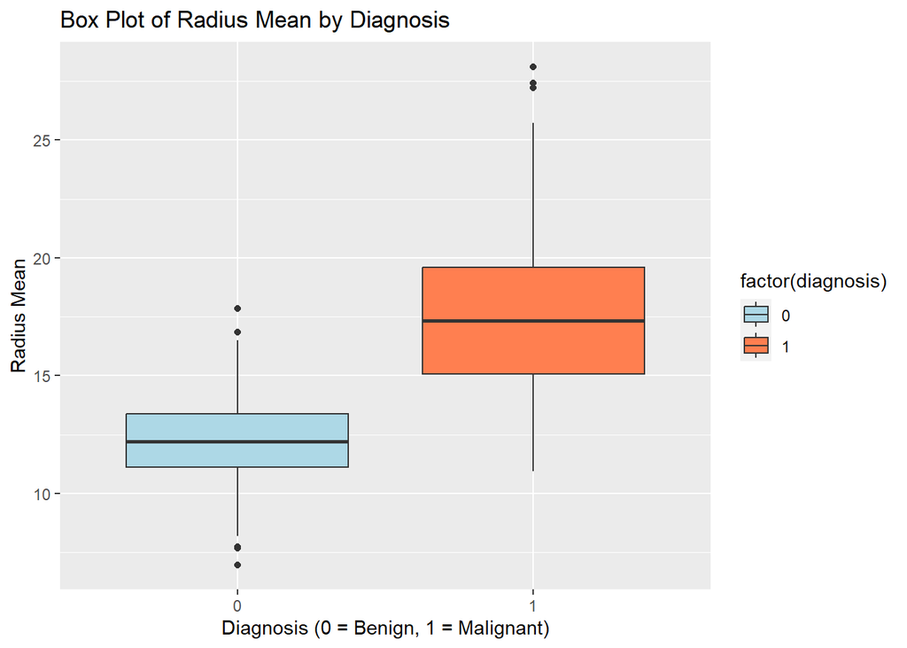

```r
# Box plot of 'radius_mean' by 'diagnosis'
ggplot(breast_cancer_data, aes(x = factor(diagnosis), y = radius_mean, fill = factor(diagnosis))) +
  geom_boxplot() +
  labs(title = "Box Plot of Radius Mean by Diagnosis", x = "Diagnosis (0 = Benign, 1 = Malignant)", y = "Radius Mean") +
  scale_fill_manual(values = c("lightblue", "coral"))
```

The box plot above displays the distribution of radius_mean across the two classes of the target variable, **diagnosis** (0 = Benign, 1 = Malignant). This plot provides insights into how the average radius of a tumor varies between benign and malignant cases.

This distinction in **radius_mean** between benign and malignant tumors suggests that **radius_mean** could be a useful predictor in distinguishing between the two classes. The clear separation in the median values indicates that larger tumor radii are associated with a higher likelihood of malignancy, making this variable a strong candidate for inclusion in predictive modeling.

# 3 Part I

## 3.1 Logistic Regression

```r
# Split data into training and testing sets
set.seed(123)  # For reproducibility
trainIndex <- sample(seq_len(nrow(breast_cancer_data)), size = 0.8 * nrow(breast_cancer_data))
training_data <- breast_cancer_data[trainIndex, ]
testing_data <- breast_cancer_data[-trainIndex, ]

# Logistic Regression Model
logistic_model <- glm(diagnosis ~ ., data = training_data, family = "binomial")

# Predict on test set
logistic_predictions <- predict(logistic_model, testing_data, type = "response")
logistic_predicted_classes <- ifelse(logistic_predictions > 0.5, 1, 0)

# Evaluate logistic regression model
logistic_conf_matrix <- confusionMatrix(factor(logistic_predicted_classes),
                                        factor(testing_data$diagnosis))
print(logistic_conf_matrix)
```

```
Confusion Matrix and Statistics

          Reference
Prediction  0  1
         0 58  0
         1  3 53

               Accuracy : 0.9737
                 95% CI : (0.925, 0.9945)
    No Information Rate : 0.5351
    P-Value [Acc > NIR] : <2e-16

                  Kappa : 0.9473

 Mcnemar's Test P-Value : 0.2482

            Sensitivity : 0.9508
            Specificity : 1.0000
         Pos Pred Value : 1.0000
         Neg Pred Value : 0.9464
             Prevalence : 0.5351
         Detection Rate : 0.5088
   Detection Prevalence : 0.5088
      Balanced Accuracy : 0.9754

       'Positive' Class : 0
```

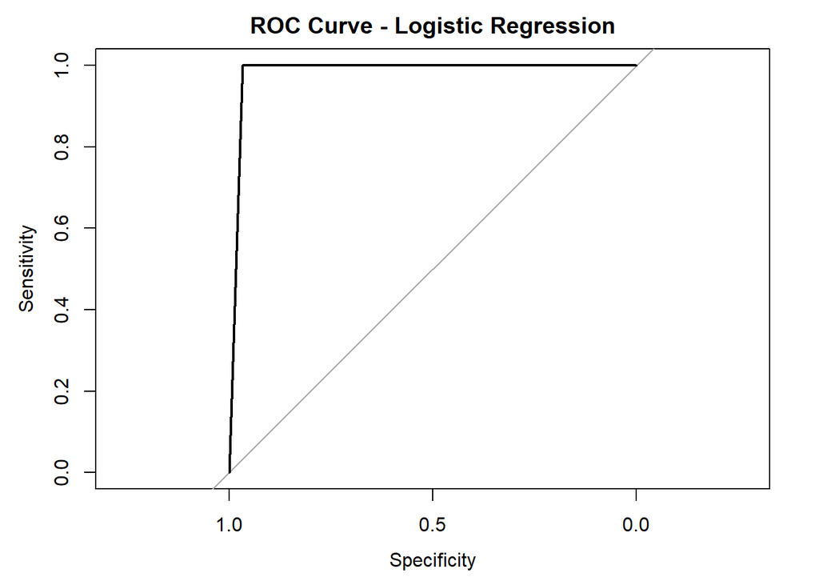

```r
# Plot ROC curve for logistic regression
logistic_roc_curve <- roc(testing_data$diagnosis, logistic_predictions)
plot(logistic_roc_curve, main = "ROC Curve - Logistic Regression")
```

The logistic regression model was used to predict whether a breast tumor is benign (0) or malignant (1) based on various features. Below is an interpretation of the results:

1. **Confusion Matrix**:
- The confusion matrix shows the model’s predictions compared to the actual classifications:
  - **True Negatives (Benign predicted as Benign)**: 58
  - **False Positives (Malignant predicted as Benign)**: 0
  - **False Negatives (Benign predicted as Malignant)**: 3
  - **True Positives (Malignant predicted as Malignant)**: 53
2. **Model Performance Metrics**:
- **Accuracy**: The model achieved an accuracy of 97.37%, indicating that it correctly predicted the tumor classification in approximately 97.4% of the cases.
- **Sensitivity (True Positive Rate)**: 95.08%, meaning the model correctly identified 95.08% of benign tumors.
- **Specificity (True Negative Rate)**: 100%, meaning the model correctly identified all malignant tumors without any false positives.
- **Positive Predictive Value (Precision)**: 100%, indicating that all tumors predicted as benign were indeed benign.
- **Negative Predictive Value**: 94.64%, meaning that 94.64% of tumors predicted as malignant were truly malignant.
3. **ROC Curve and AUC**:
- The ROC curve for this model shows a strong separation between the two classes, with the curve hugging the top-left corner of the plot. This suggests excellent model performance.
- The high specificity and sensitivity values contribute to an area under the curve (AUC) close to 1, indicating that the model effectively distinguishes between benign and malignant tumors.
4. **Overall Model Interpretation**:
- The high accuracy, sensitivity, and specificity values indicate that the logistic regression model performs exceptionally well on this dataset, with minimal misclassifications. This performance, combined with the ROC curve, suggests that the model is highly effective at identifying both benign and malignant tumors.
- However, the model’s perfect specificity may be partly due to class imbalance or the characteristics of this particular dataset. Testing the model on a new dataset would help determine its generalizability.

## 3.2 Single-Layer Neural Network Model

```r
# Load library for neural networks
library(nnet)

# Fit a single-layer neural network model
# The "size" parameter specifies the number of units in the hidden layer
nn_model <- nnet(diagnosis ~ ., data = training_data, size = 5, linout = FALSE, maxit = 200)
# Predict on the test set
nn_predictions <- predict(nn_model, testing_data, type = "raw")
nn_predicted_classes <- ifelse(nn_predictions > 0.5, 1, 0)

# Evaluate the neural network model
nn_conf_matrix <- confusionMatrix(factor(nn_predicted_classes), factor(testing_data$diagnosis))
print(nn_conf_matrix)
```

```
Confusion Matrix and Statistics

          Reference
Prediction  0  1
         0 61 53
         1  0  0

               Accuracy : 0.5351
                 95% CI : (0.4393, 0.629)
    No Information Rate : 0.5351
    P-Value [Acc > NIR] : 0.5382

                  Kappa : 0

 Mcnemar's Test P-Value : 9.148e-13

            Sensitivity : 1.0000
            Specificity : 0.0000
         Pos Pred Value : 0.5351
         Neg Pred Value :    NaN
             Prevalence : 0.5351
         Detection Rate : 0.5351
   Detection Prevalence : 1.0000
      Balanced Accuracy : 0.5000

       'Positive' Class : 0
```

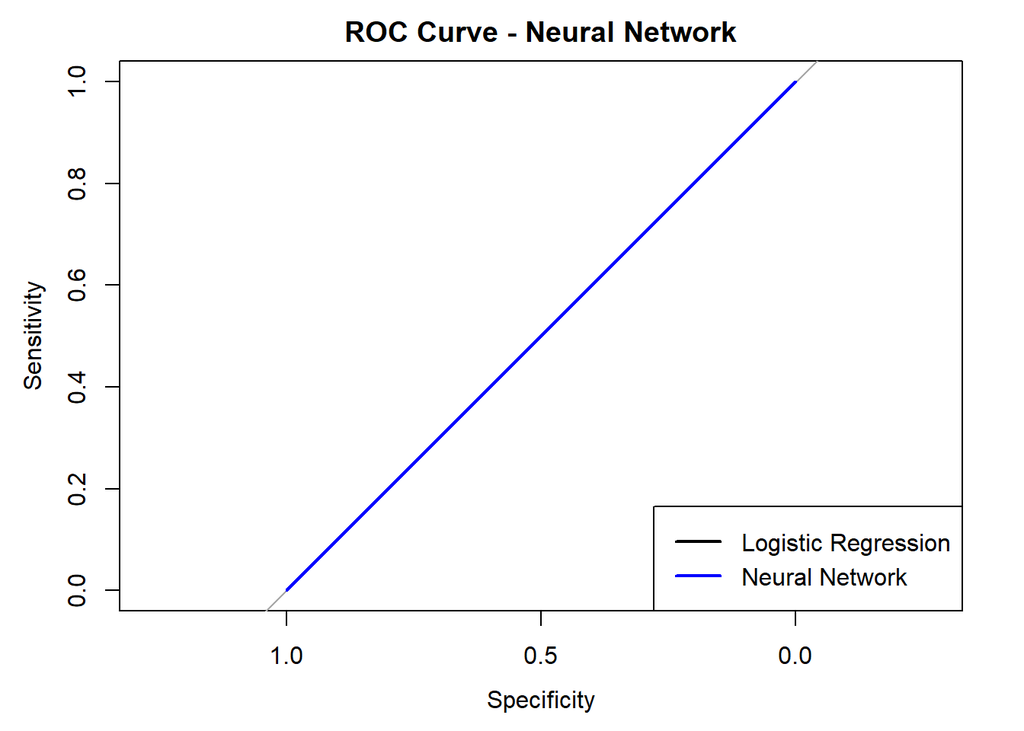

```r
# Plot ROC curve for neural network
nn_roc_curve <- roc(testing_data$diagnosis, as.numeric(nn_predictions))
plot(nn_roc_curve, col = "blue", main = "ROC Curve - Neural Network")

# Add legend to ROC plot if you want to compare it with logistic regression
legend("bottomright", legend = c("Logistic Regression", "Neural Network"),
       col = c("black", "blue"), lwd = 2)
```

The single-layer neural network model was applied to classify breast tumors as benign (0) or malignant (1). However, the model’s performance was poor based on the confusion matrix and ROC curve results:

1. **Confusion Matrix**:
- The confusion matrix shows that the model classified all cases as benign (0), resulting in:
  - **True Negatives (Benign predicted as Benign)**: 61
  - **False Positives (Malignant predicted as Benign)**: 53
  - **False Negatives (Benign predicted as Malignant)**: 0
  - **True Positives (Malignant predicted as Malignant)**: 0
- This misclassification pattern indicates that the neural network failed to differentiate between benign and malignant tumors, predicting all cases as benign.
2. **Model Performance Metrics**:
- **Accuracy**: The model achieved an accuracy of 53.51%, which is equivalent to the no-information rate (NIR). This suggests that the model’s performance is no better than random guessing.
- **Sensitivity (True Positive Rate)**: 100%, meaning the model correctly identified all benign cases but only because it predicted every case as benign.
- **Specificity (True Negative Rate)**: 0%, meaning the model failed to identify any malignant cases correctly.
- **Balanced Accuracy**: 50%, indicating the model has no discriminatory power between classes.
3. **ROC Curve and AUC**:
- The ROC curve shows a diagonal line, indicating that the model’s performance is equivalent to random guessing. The lack of separation between the classes suggests that the neural network is not able to distinguish benign from malignant tumors in this setup.
4. **Overall Model Interpretation**:
- The single-layer neural network model did not perform well on this dataset. Possible reasons for this could include the need for tuning parameters such as the number of hidden units (**size**) or training iterations (**maxit**). Another factor may be that a single-layer neural network is too simple for this dataset, and a more complex neural network with additional hidden layers or a different structure might yield better results.
- Given the poor performance, this model may not be suitable for predicting tumor classifications in this analysis without further optimization.

# 4 Part II

## 4.1 Decision Algorithm Implementation

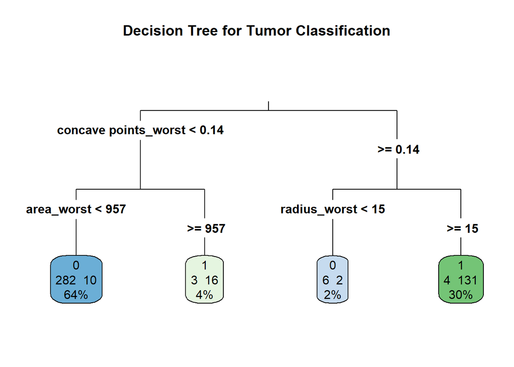

```r
# Load necessary libraries
library(rpart)
library(rpart.plot)
library(pROC)

# Fit a decision tree model
tree_model <- rpart(diagnosis ~ ., data = training_data, method = "class")

# Plot the decision tree for interpretation
rpart.plot(tree_model, type = 3, extra = 101, fallen.leaves = TRUE, main = "Decision Tree for Tumor Classification")
```

```r
# Predict on the test set
tree_predictions <- predict(tree_model, testing_data, type = "prob")[, 2]
tree_predicted_classes <- ifelse(tree_predictions > 0.5, 1, 0)

# Evaluate the decision tree model
tree_conf_matrix <- confusionMatrix(factor(tree_predicted_classes), factor(testing_data$diagnosis))
print(tree_conf_matrix)
```

```
Confusion Matrix and Statistics

          Reference
Prediction  0  1
         0 59  4
         1  2 49

               Accuracy : 0.9474
                 95% CI : (0.889, 0.9804)
    No Information Rate : 0.5351
    P-Value [Acc > NIR] : <2e-16

                  Kappa : 0.894

 Mcnemar's Test P-Value : 0.6831

            Sensitivity : 0.9672
            Specificity : 0.9245
         Pos Pred Value : 0.9365
         Neg Pred Value : 0.9608
             Prevalence : 0.5351
         Detection Rate : 0.5175
   Detection Prevalence : 0.5526
      Balanced Accuracy : 0.9459

       'Positive' Class : 0
```

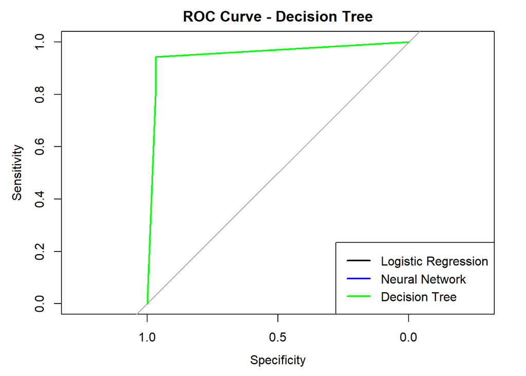

```r
# Plot ROC curve for the decision tree
tree_roc_curve <- roc(testing_data$diagnosis, tree_predictions)
plot(tree_roc_curve, col = "green", main = "ROC Curve - Decision Tree")

# Add legend to ROC plot for comparison
legend("bottomright", legend = c("Logistic Regression", "Neural Network", "Decision Tree"),
       col = c("black", "blue", "green"), lwd = 2)
```

The decision tree model was implemented to classify breast tumors as benign (0) or malignant (1) based on various features. Below is an interpretation of the results:

1. **Decision Tree Structure**:
- The decision tree visualization shows the key splits used by the model to classify tumors. The top decision node splits based on **concave points_worst**, which indicates that this feature is highly influential in distinguishing between benign and malignant tumors.
- Additional splits are made on **area_worst** and **radius_worst**, further refining the classification.
- The leaf nodes display the predicted class (0 or 1), the number of cases in each node, and the percentage of cases in the dataset, providing an intuitive view of the classification process.
2. **Confusion Matrix**:
- The confusion matrix indicates the model’s predictions compared to the actual classifications:
  - **True Negatives (Benign predicted as Benign)**: 59
  - **False Positives (Malignant predicted as Benign)**: 4
  - **False Negatives (Benign predicted as Malignant)**: 2
  - **True Positives (Malignant predicted as Malignant)**: 49
3. **Model Performance Metrics**:
- **Accuracy**: The model achieved an accuracy of 94.74%, indicating a high level of overall correct classifications.
- **Sensitivity (True Positive Rate)**: 96.72%, meaning the model correctly identified 96.72% of benign tumors.
- **Specificity (True Negative Rate)**: 92.45%, indicating that the model correctly identified 92.45% of malignant tumors.
- **Positive Predictive Value (Precision)**: 93.65%, indicating that when the model predicts a tumor as benign, it is correct 93.65% of the time.
- **Negative Predictive Value**: 96.08%, meaning that when the model predicts a tumor as malignant, it is correct 96.08% of the time.
4. **ROC Curve and AUC**:
- The ROC curve for the decision tree model closely approaches the top-left corner of the plot, indicating strong model performance.
- The decision tree’s performance appears similar to the logistic regression model, with both models achieving a high area under the curve (AUC), reflecting effective discrimination between benign and malignant tumors.
5. Overall Model Interpretation:
- The decision tree model provides high accuracy and balanced sensitivity and specificity, making it a strong model for this classification task. Additionally, the decision tree structure allows for easy interpretation, as it highlights the most important features (**concave points_worst**, **area_worst**, and **radius_worst**) for classifying tumors.
- The decision tree model’s performance is comparable to the logistic regression model, and it offers the added benefit of being easily interpretable, which can be valuable in medical diagnostics.

## 4.2 Model Comparison using ROC Analysis

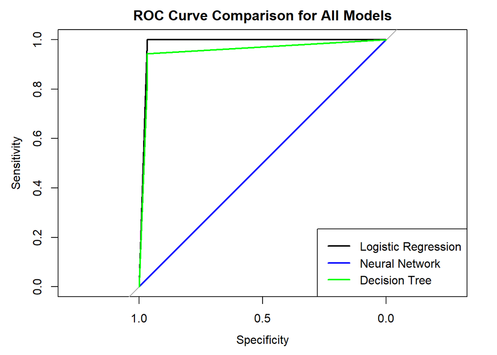

```r
# Plot ROC curves for all three models on the same plot for comparison

# Logistic Regression ROC curve
logistic_roc_curve <- roc(testing_data$diagnosis, logistic_predictions)
plot(logistic_roc_curve, col = "black", lwd = 2, main = "ROC Curve Comparison for All Models")

# Neural Network ROC curve
nn_roc_curve <- roc(testing_data$diagnosis, as.numeric(nn_predictions))
plot(nn_roc_curve, col = "blue", add = TRUE, lwd = 2)

# Decision Tree ROC curve
tree_roc_curve <- roc(testing_data$diagnosis, tree_predictions)
plot(tree_roc_curve, col = "green", add = TRUE, lwd = 2)

# Add legend to differentiate models
legend("bottomright", legend = c("Logistic Regression", "Neural Network", "Decision Tree"),
       col = c("black", "blue", "green"), lwd = 2)
```

```r
# Calculate and display AUC for each model
logistic_auc <- auc(logistic_roc_curve)
nn_auc <- auc(nn_roc_curve)
tree_auc <- auc(tree_roc_curve)

print(paste("Logistic Regression AUC:", round(logistic_auc, 3)))
```

```
[1] "Logistic Regression AUC: 0.984"
```

```r
print(paste("Neural Network AUC:", round(nn_auc, 3)))
```

```
[1] "Neural Network AUC: 0.5"
```

```r
print(paste("Decision Tree AUC:", round(tree_auc, 3)))
```

```
[1] "Decision Tree AUC: 0.953"
```

To evaluate the performance of the logistic regression, neural network, and decision tree models, we compared their ROC curves and calculated their AUC (Area Under the Curve) values. A higher AUC indicates a better-performing model, as it reflects a stronger ability to distinguish between benign and malignant tumors.

1. **Logistic Regression**:
- **AUC**: 0.984
- The logistic regression model performed exceptionally well, achieving the highest AUC of 0.984. Its ROC curve is close to the top-left corner, indicating excellent sensitivity and specificity.
2. **Neural Network**:
- **AUC**: 0.5
- The single-layer neural network model performed poorly, with an AUC of 0.5. This AUC value suggests that the model’s performance is equivalent to random guessing, as seen by its diagonal ROC curve. This model did not effectively distinguish between the two classes in this dataset.
3. **Decision Tree**:
- **AUC**: 0.953

The decision tree model also performed well, achieving an AUC of 0.953. Its ROC curve is close to that of the logistic regression model, indicating strong classification performance. However, it slightly underperforms compared to logistic regression.

**Conclusion**

Based on the ROC analysis and AUC values, the **logistic regression model** is the best-performing model, with the highest AUC of 0.984. This model demonstrates the strongest ability to correctly classify benign and malignant tumors, making it the most reliable choice for this task. While the decision tree model also performed well with an AUC of 0.953, the logistic regression model provides a marginally better classification performance. The neural network model, with an AUC of 0.5, did not perform adequately in this analysis.

# 5 Part III

## 5.1 Implementing the BAGGING Algorithm

```r
# Install and load the randomForest package if not already installed
if (!require(randomForest)) {
  install.packages("randomForest")
  library(randomForest)
} else {
  library(randomForest)
}
```

```r
# Ensure all column names are syntactically valid
colnames(training_data) <- make.names(colnames(training_data))
colnames(testing_data) <- make.names(colnames(testing_data))

# Ensure diagnosis is a factor in both training and testing datasets
training_data$diagnosis <- factor(training_data$diagnosis)
testing_data$diagnosis <- factor(testing_data$diagnosis)

# Fit the Random Forest model (bagging with decision trees)
set.seed(123)  # For reproducibility
rf_model <- randomForest(diagnosis ~ ., data = training_data, ntree = 50)

# Predict probabilities on the test set
rf_predictions <- predict(rf_model, testing_data, type = "prob")[, 2]
rf_predicted_classes <- ifelse(rf_predictions > 0.5, 1, 0)

# Evaluate the Bagging model (Random Forest)
rf_conf_matrix <- confusionMatrix(factor(rf_predicted_classes), factor(testing_data$diagnosis))
print(rf_conf_matrix)
```

```
Confusion Matrix and Statistics

          Reference
Prediction  0  1
         0 61  2
         1  0 51

               Accuracy : 0.9825
                 95% CI : (0.9381, 0.9979)
    No Information Rate : 0.5351
    P-Value [Acc > NIR] : <2e-16

                  Kappa : 0.9647

 Mcnemar's Test P-Value : 0.4795

            Sensitivity : 1.0000
            Specificity : 0.9623
         Pos Pred Value : 0.9683
         Neg Pred Value : 1.0000
             Prevalence : 0.5351
         Detection Rate : 0.5351
   Detection Prevalence : 0.5526
      Balanced Accuracy : 0.9811

       'Positive' Class : 0
```

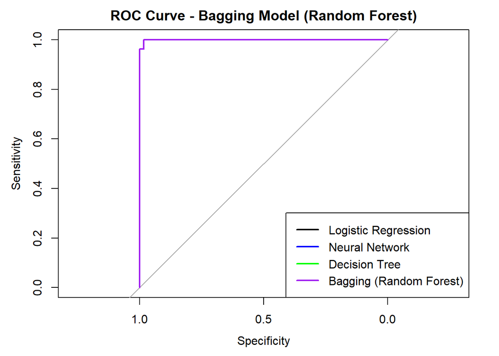

```r
# Plot ROC curve for Bagging model (Random Forest)
rf_roc_curve <- roc(testing_data$diagnosis, rf_predictions)
plot(rf_roc_curve, col = "purple", main = "ROC Curve - Bagging Model (Random Forest)")

# Add legend to compare with other models
legend("bottomright", legend = c("Logistic Regression", "Neural Network", "Decision Tree", "Bagging (Random Forest)"),
       col = c("black", "blue", "green", "purple"), lwd = 2)
```

The bagging model, implemented using a random forest with decision trees as base learners, was evaluated for its effectiveness in classifying breast tumors as benign (0) or malignant (1). Here’s a summary of the results:

1. **Confusion Matrix**:
- The confusion matrix shows the model’s predictions compared to the actual classifications:
  - **True Negatives (Benign predicted as Benign)**: 61
  - **False Positives (Malignant predicted as Benign)**: 2
  - **False Negatives (Benign predicted as Malignant)**: 0
  - **True Positives (Malignant predicted as Malignant)**: 51
2. Model Performance Metrics:
- **Accuracy**: The model achieved an accuracy of 98.25%, indicating a high level of correct classifications.
- **Sensitivity (True Positive Rate)**: 100%, meaning the model correctly identified all benign tumors.
- **Specificity (True Negative Rate)**: 96.23%, indicating that the model correctly identified 96.23% of malignant tumors.
- **Positive Predictive Value (Precision)**: 96.83%, showing that 96.83% of the cases predicted as benign were truly benign.
- **Negative Predictive Value**: 100%, indicating that all cases predicted as malignant were indeed malignant.
3. **ROC Curve and AUC**:
- The ROC curve for the bagging model (purple) shows a strong performance with a curve close to the top-left corner, indicating excellent sensitivity and specificity.
- The bagging model’s ROC curve closely aligns with that of the logistic regression and decision tree models, suggesting comparable or slightly improved performance.
4. **Overall Model Interpretation**:
- The bagging model performed exceptionally well, achieving high accuracy, sensitivity, and specificity. This strong performance indicates that the ensemble approach of bagging contributed to better classification accuracy and robustness.
- Compared to the other models, the bagging model offers a slightly higher accuracy and balanced accuracy, making it a strong candidate for tumor classification tasks.

**Conclusion**